# Lab 14 - Bivariate Regression & Interpretation

Yana Chakalo

November 28, 2017

Complete the following exercises below and include all code used to find the answers. Knit together the PDF document and commit both the Lab 14 RMD file and the PDF document to Git. Push the changes to GitHub so both documents are visible in your public GitHub repository.

**1. Select the main focal relationship you’re interested in exploring for your poster project.**

## Installing packages that i might need to use.

```r
options(repos = c(CRAN = "http://cran.rstudio.com"))
install.packages("dplyr")
install.packages("packrat")
install.packages("readr")
install.packages("foreign")
install.packages("haven")
install.packages("knitr")
install.packages("tidyverse")
library("tidyverse")
library("dplyr")
library("packrat")
library("readr")
library("foreign")
library("haven")
library("knitr")
```

```r
setwd("/Users/soniachakalo/Downloads/Final.Porject.Labs")

opts_knit$set(root.dir = "/Users/soniachakalo/Downloads/Final.Porject.Labs")

getwd()
```

```
## [1] "/Users/soniachakalo/Downloads/Final.Porject.Labs"
```

## Downloading my data set and which variables i want to this lab and to Rstudio.

# Read in your data with the appropriate function

# replace with variable’s you wish to add

# 2002

```r
data2 <- read_tsv("/Users/soniachakalo/Downloads/Final.Porject.Labs/23625_0002_Data.tsv")
data_subset2 <- data2 %>%
  select(CITY, STATECOD, POP1, TNUMVTMS, TNUMOFF, GOFFRAC, BIASMO1, VTYP_I1, LOCCOD1, VTYP_I1, LOCCOD1)
```

# 2013

```r
data13 <- read_tsv("/Users/soniachakalo/Downloads/Final.Porject.Labs/36118-0002-Data.tsv")
data_subset13 <- data13 %>%
  select(CITY, STATECOD, POP1, TNUMVTMS, TNUMOFF, GOFFRAC, BIASMO1, VTYP_I1, LOCCOD1, VTYP_I1, LOCCOD1)
# replace with variable's you wish to add
```

1. Describe the response variable and the explanatory variable and the theoretical relationship you believe exists between these two variables.

The two variables that I want to look at is the bias motivation (BIASMO1) of the hate crime and the offenders race of the hate crime. The explantory variable (x variable) is the offenders race and the response variable (y variable) is the bias motivation. I think these two exist in a relationship because hate crimes are a specific type of crime that focuses on someones identity so in theory the offenders race would thus determine what the bias motivation behind the hate crime was.

2. Conduct a simple (bivariate) linear regression on your focal relationship and save the model object. Print out the full results by calling `summary()` on your model object.

# 2002

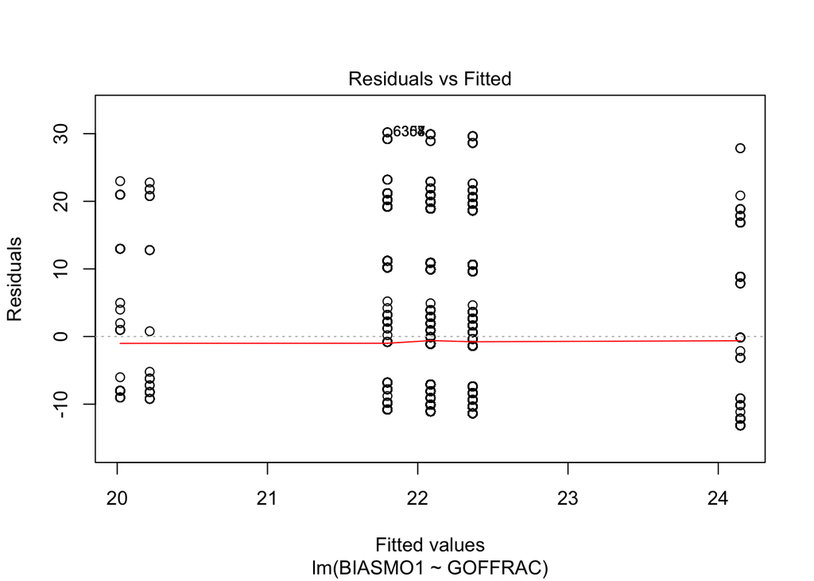

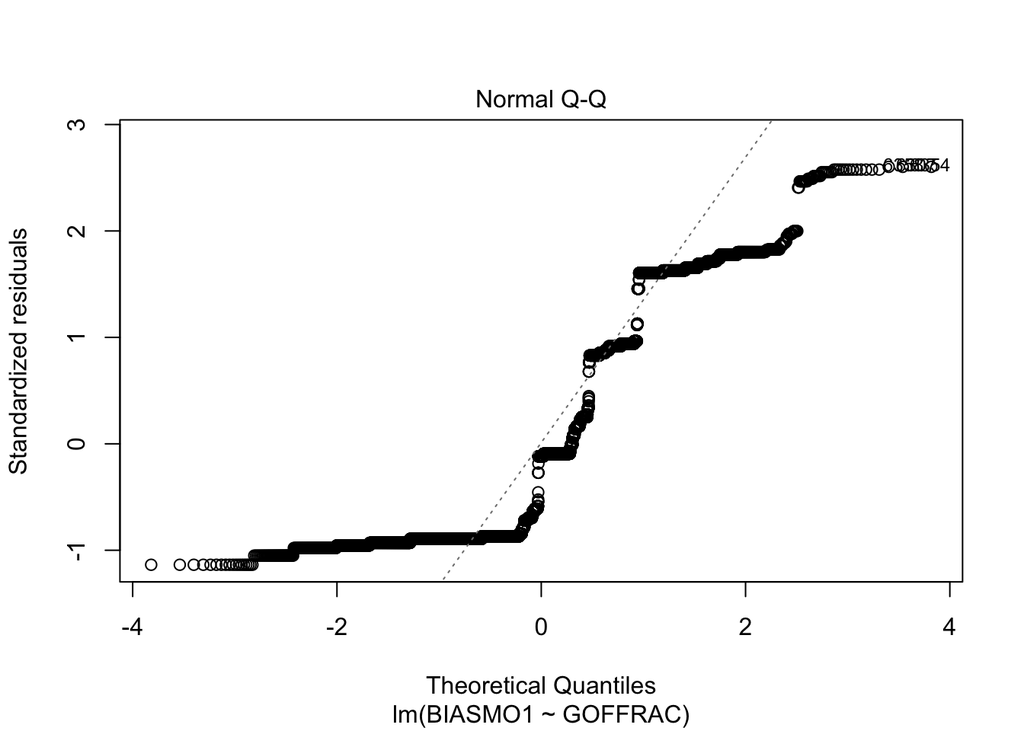

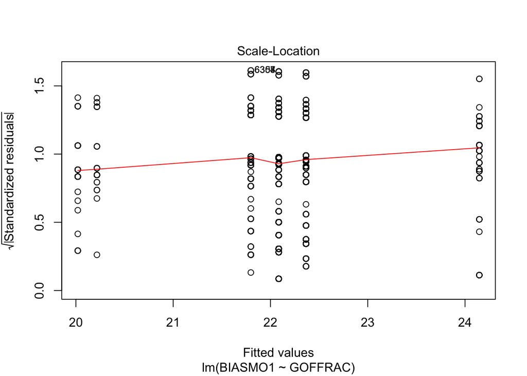

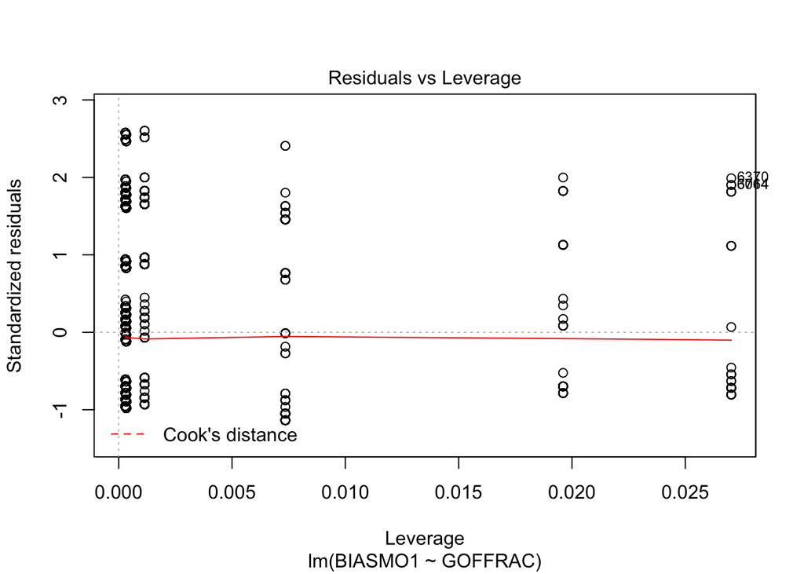

```r
BIASMO1_GOFFRAC <- lm(formula = BIASMO1 ~ GOFFRAC, data = data_subset2)

plot(BIASMO1_GOFFRAC)
```

```r
summary(BIASMO1_GOFFRAC)
```

```
##
## Call:
## lm(formula = BIASMO1 ~ GOFFRAC, data = data_subset2)
##
## Residuals:
##     Min      1Q  Median      3Q     Max
## -13.147 -10.366  -1.366  10.634  30.202
##
## Coefficients:
##             Estimate Std. Error t value Pr(>|t|)
## (Intercept)  20.0196     1.6260  12.312   <2e-16 ***
## GOFFRACB      1.7788     1.6728   1.063   0.2877
## GOFFRACI      0.1966     2.5076   0.078   0.9375
## GOFFRACM      4.1275     1.9066   2.165   0.0304 *
## GOFFRACU      2.0657     1.6383   1.261   0.2074
## GOFFRACW      2.3461     1.6397   1.431   0.1525
## ---
## Signif. codes:  0 '***' 0.001 '**' 0.01 '*' 0.05 '.' 0.1 ' ' 1
##
## Residual standard error: 11.61 on 7456 degrees of freedom
## Multiple R-squared:  0.00116,    Adjusted R-squared:  0.0004903
## F-statistic: 1.732 on 5 and 7456 DF,  p-value: 0.1236
```

# 2013

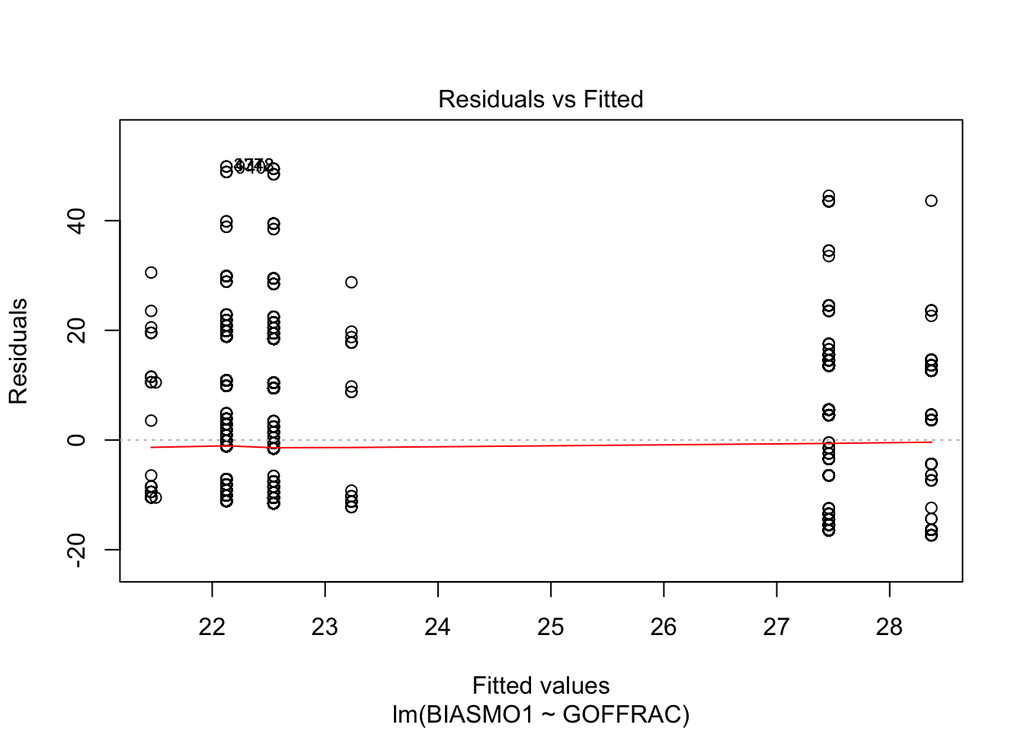

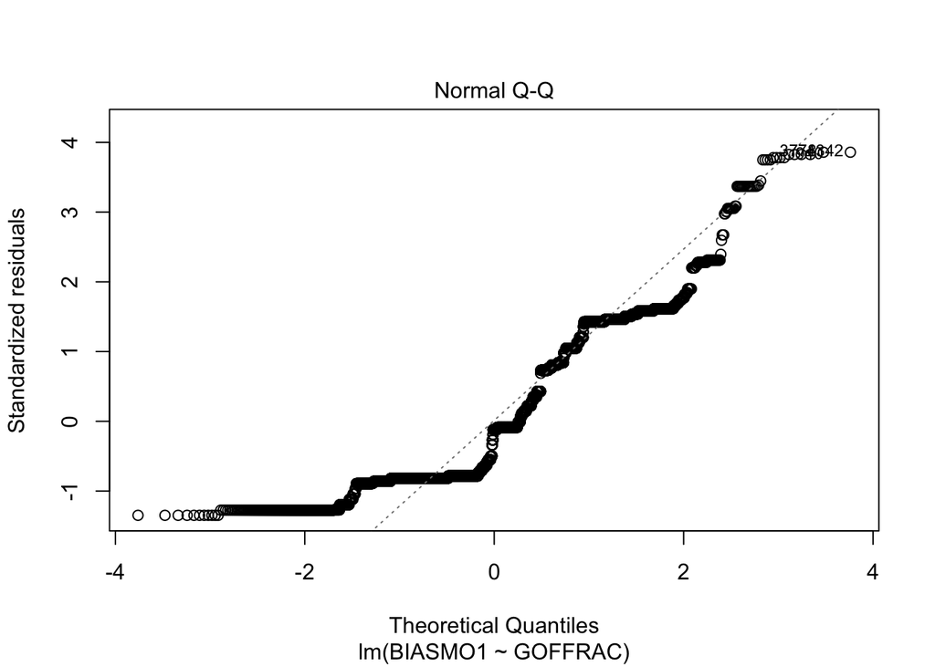

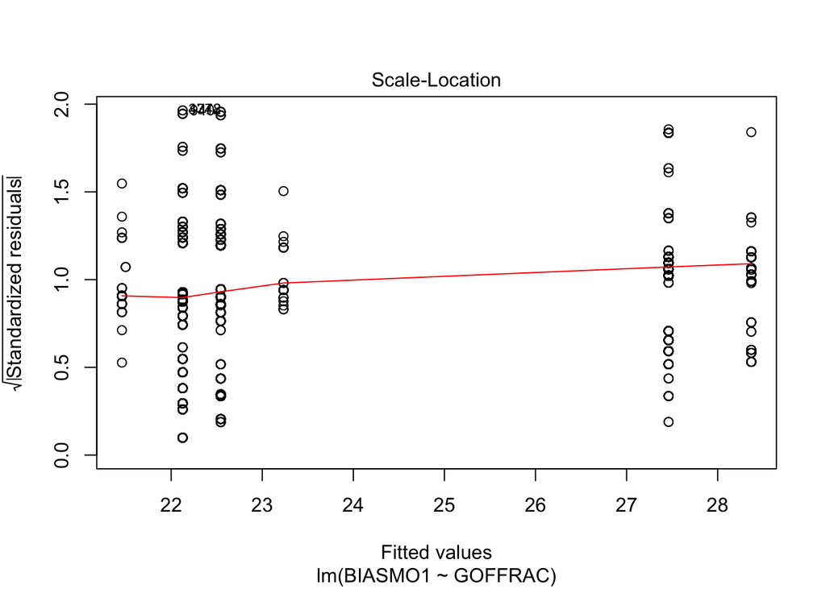

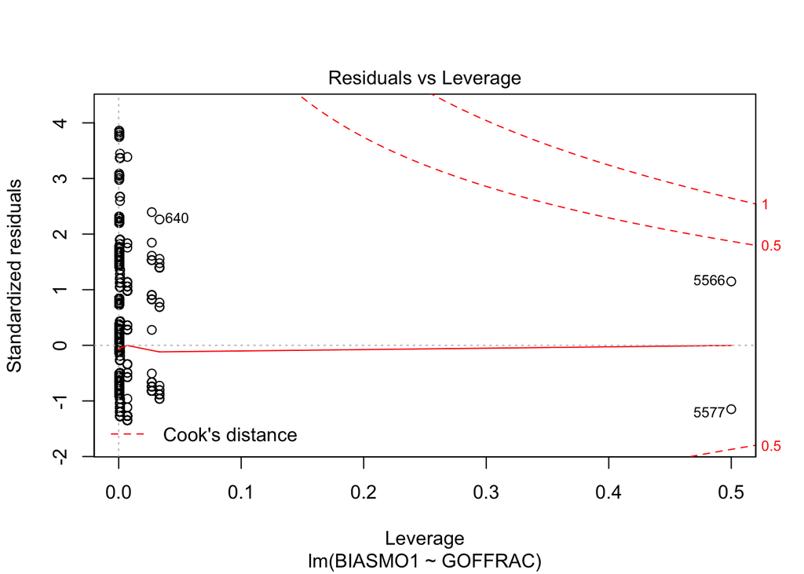

```r
BIASMO1_GOFFRAC <- lm(formula = BIASMO1 ~ GOFFRAC, data = data_subset13)

plot(BIASMO1_GOFFRAC)
```

```r
summary(BIASMO1_GOFFRAC)
```

```
##
## Call:
## lm(formula = BIASMO1 ~ GOFFRAC, data = data_subset13)
##
## Residuals:
##     Min      1Q  Median      3Q     Max
## -17.369 -10.544  -1.544  10.791  49.874
##
## Coefficients:
##             Estimate Std. Error t value Pr(>|t|)
## (Intercept)  23.2333     2.3604   9.843   <2e-16 ***
## GOFFRACB      4.2277     2.3985   1.763   0.0780 .
## GOFFRACI     -1.7739     3.1764  -0.558   0.5766
## GOFFRACM      5.1355     2.5995   1.976   0.0482 *
## GOFFRACP     -1.7333     9.4418  -0.184   0.8543
## GOFFRACU     -1.1074     2.3750  -0.466   0.6410
## GOFFRACW     -0.6893     2.3755  -0.290   0.7717
## ---
## Signif. codes:  0 '***' 0.001 '**' 0.01 '*' 0.05 '.' 0.1 ' ' 1
##
## Residual standard error: 12.93 on 5907 degrees of freedom
## Multiple R-squared:  0.02416,    Adjusted R-squared:  0.02316
## F-statistic: 24.37 on 6 and 5907 DF,  p-value: < 2.2e-16
```

3. What is the direction, magnitude, and statistical significance of the bivariate association between the explanatory and response variables.

First the 2002 data does not follow a noraml distribution because the points are very far off the linear line. In the 2013 data it follows the noraml distribution better than the 2002 data but still is not following the line so this data too is not on a normal distribution. Statistical significance of 2002 data is shown through the p-value which is 0.1236. Which means that the p-value is high which my data are likely with a true null. Which means that I fail to reject the null hypoethsis meaning my data is lilekly with a true null hypotehsis. So the 2002 data statistical signinficance is showing there is little significance and no affect between these two variables. The 2013 p-value is 2.2^-16 is a low p-value meaning data are unlikely with a true null. So this means that the 2013 data between these to varaibles has a high statistical significance and relatable. My 2002 and 2013 data intercept is a positive association.

4. What is the meaning of the model intercept?

The model intercept for 2002 is about 20 and the 2013 data is about 23. This means that the mean of Y when all predictors equals zero. However, this data is only meaningful if X does have some values of zero but since my values are categorical there is no meaningful zeros so the slope intercept for this model has no meaning.

5. How well does the bivariate model fit the data? How is this information calculated?

The bivariate model does not fit my data that much because both of my variables are categorical so when calculating a regression model, intercept, and means the numbers do not have any meangingful numeric value when caluclated for a bivariate model.

6. Is the observed association between the independent variable and dependent variable consistent with your hypothesis? Why or why not?

When looking at the p-value’s of both the datas I would say that for 2002 it does not make sense beacause the p-value is pretty big meaning there is not a signigicant association while the 2013 data with the same variables have a small p-value meaning the statistical significance is high. So maybe this means that back in 2002 the offenders race did not determine the bias motive of the hate crime but in 2013 the race does matter determinging the bias motive. Or that the data is getting two different results because this bivariate model does not fit my data nor does is accuratley represent this association.

**2. Select a different focal relationship related to your project. This could be:**

- **A different response and a different explanatory variable**
- **A different response and the same explanatory variable**
- **The same response and a different explanatory variable**
1. Describe the response variable and the explanatory variable and the theoretical relationship you believe exists between these two variables.

The response variable is the location of the hate crime (LOCCOD1) and the explanatory variable is the bias motivation of the hate crime (BIASMO1). The location of the hate crime could explain what the bias motive behind the crime is because where crimes occur matters a lot in understanding what the circumstances of the crime and its people involved are in. So i can see that the specific locations of the crimes can help us understand what the motovation behind these crimes are and even who the offenders / victims were.

2. Conduct a simple (bivariate) linear regression on your focal relationship and save the model object. Print out the full results by calling `summary()` on your model object.

# 2002

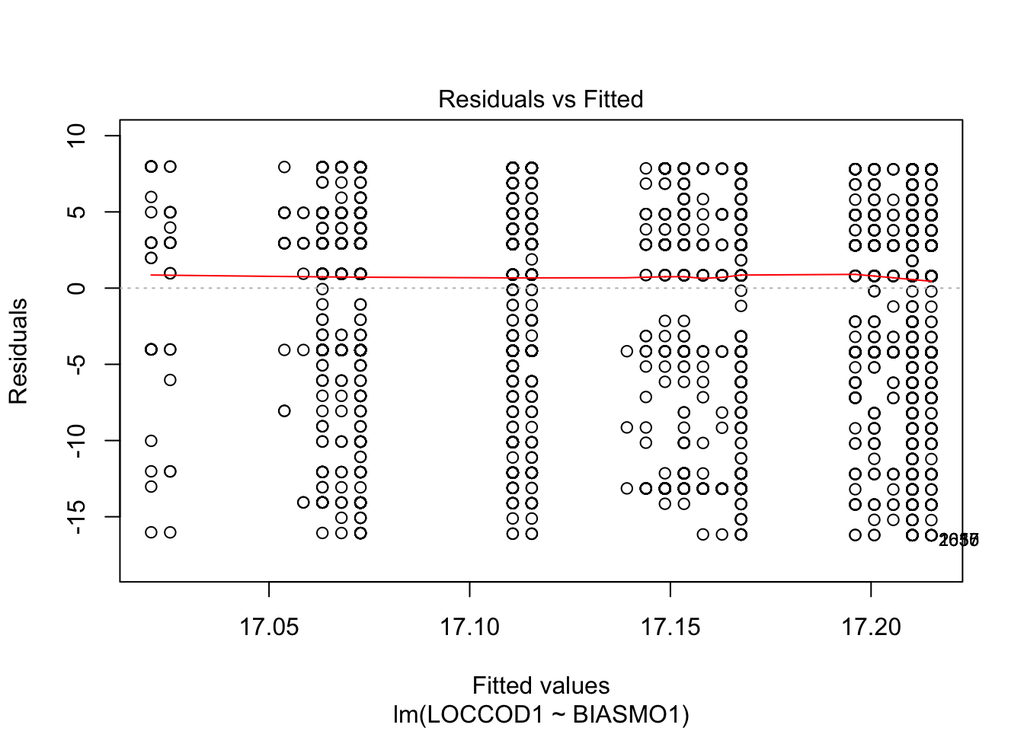

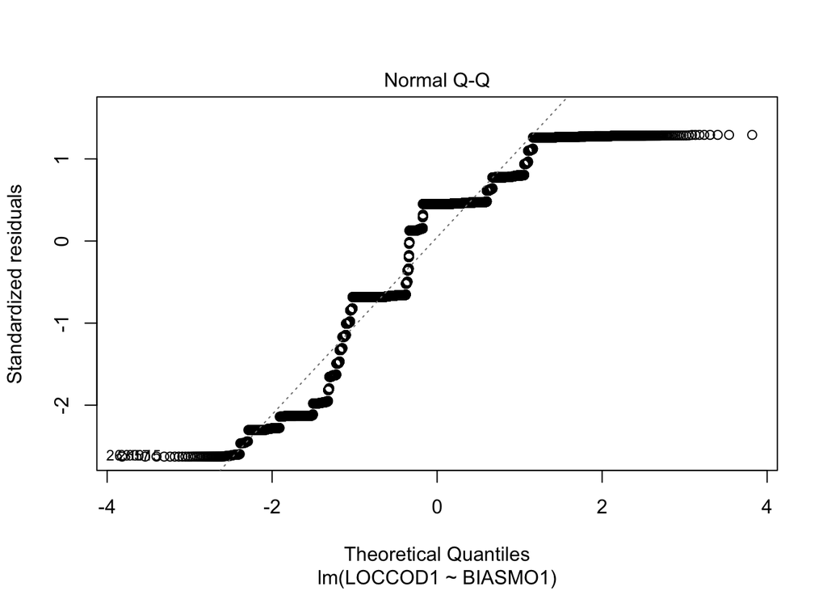

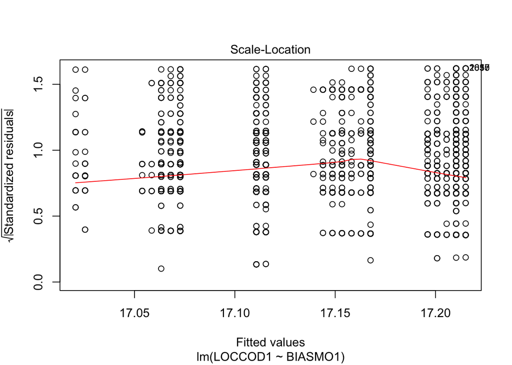

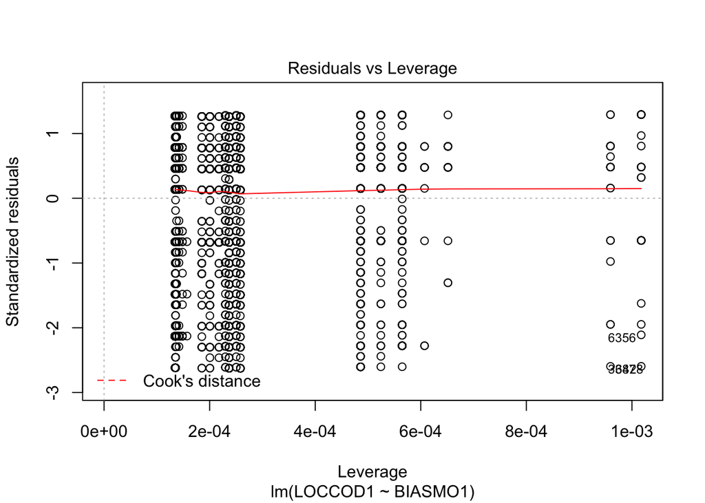

```r
LOCCOD1_BIASMO1 <- lm(formula = LOCCOD1 ~ BIASMO1, data = data_subset2)

plot(LOCCOD1_BIASMO1)
```

```r
summary(LOCCOD1_BIASMO1)
```

```
##
## Call:
## lm(formula = LOCCOD1 ~ BIASMO1, data = data_subset2)
##
## Residuals:
##     Min      1Q  Median      3Q     Max
## -16.215  -4.210   2.790   4.785   7.979
##
## Coefficients:
##              Estimate Std. Error t value Pr(>|t|)
## (Intercept) 17.267174   0.154100  112.05   <2e-16 ***
## BIASMO1     -0.004741   0.006155   -0.77    0.441
## ---
## Signif. codes:  0 '***' 0.001 '**' 0.01 '*' 0.05 '.' 0.1 ' ' 1
##
## Residual standard error: 6.175 on 7460 degrees of freedom
## Multiple R-squared:  7.953e-05,  Adjusted R-squared:  -5.451e-05
## F-statistic: 0.5933 on 1 and 7460 DF,  p-value: 0.4412
```

# 2013

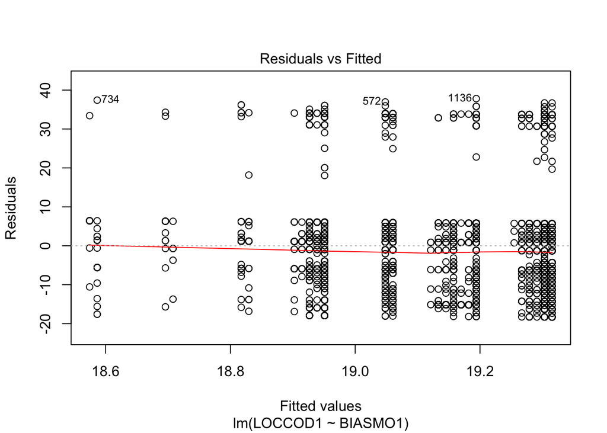

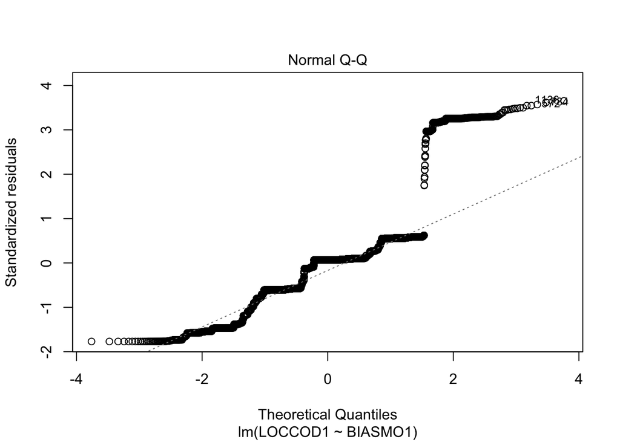

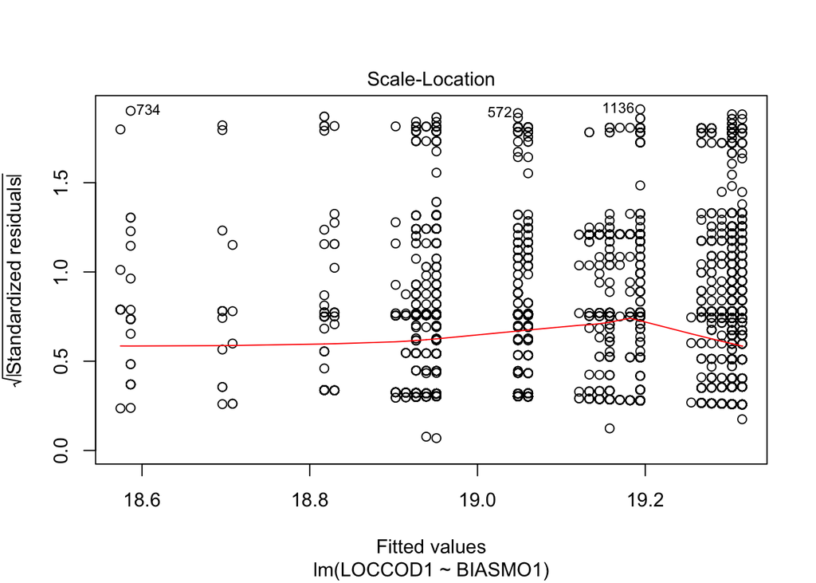

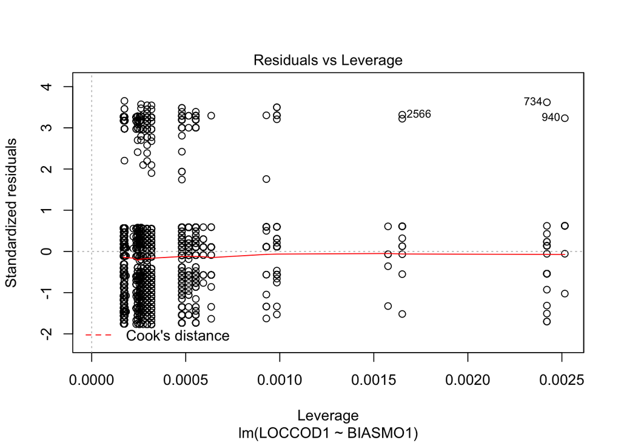

```r
LOCCOD1_BIASMO1 <- lm(formula = LOCCOD1 ~ BIASMO1, data = data_subset13)

plot(LOCCOD1_BIASMO1)
```

```r
summary(LOCCOD1_BIASMO1)
```

```
##
## Call:
## lm(formula = LOCCOD1 ~ BIASMO1, data = data_subset13)
##
## Residuals:
##     Min      1Q  Median      3Q     Max
## -18.316  -6.194   0.697   2.684  37.806
##
## Coefficients:
##             Estimate Std. Error t value Pr(>|t|)
## (Intercept) 19.44923    0.27470  70.801   <2e-16 ***
## BIASMO1     -0.01215    0.01029  -1.181    0.238
## ---
## Signif. codes:  0 '***' 0.001 '**' 0.01 '*' 0.05 '.' 0.1 ' ' 1
##
## Residual standard error: 10.35 on 5912 degrees of freedom
## Multiple R-squared:  0.0002359,  Adjusted R-squared:  6.679e-05
## F-statistic: 1.395 on 1 and 5912 DF,  p-value: 0.2376
```

3. What is the direction, magnitude, and statistical significance of the bivariate association between the explanatory and response variables.

4. What is the meaning of the model intercept?

Again for this data both varaibles are categorical so the intercept has no meaning in relation to my data.

5. How well does the bivariate model fit the data? How is this information calculated?

This data does not fit bivariate models very well because the variables are categorical. So the numbers are just a category placed for each level.

6. Is the observed association between the independent variable and dependent variable consistent with your hypothesis? Why or why not?

When looking at the p-value the statistical significance for both data was not that surprising because location of a crime can be more maliable and less meaningful since location type can be defined with many different labels. However, I was surpised at how high the p-values were and I thought that location would be associated a little more with bias motivation because the location of a crime can be very telling too. I would have to look at other models to run to find an association or not with more coinfidence.